# Solution_case-study_logisticRegression

### Age vs Risk vs Job

- more chances to default--younger customers compare to elder customers

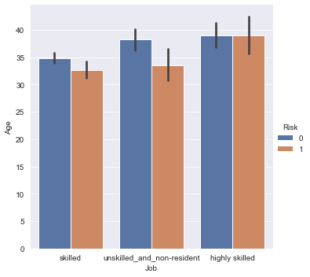

```python
sns.catplot(data=data2, x="Job", y="Age", hue="Risk", kind="bar")
```

- no interesting insight

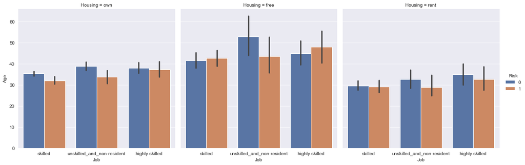

```python
sns.catplot(data=data2, x="Job", y="Age", col="Housing", hue="Risk", kind="bar")
```

- defaulters who have housing=free, job=higly_skilled are elder than the non-defaulter but overall defaulters are younger than the non-defaulters

### Purpose vs Risk vs Age

- more chance to default-- persons who have taken credit for vacation/education or for other purposes compare to others
- less chances to default-- persons who have taken credit for the purpose of radio/TV compare to others
- more chances to default--younger customers compare to elder customers

```
(array([0, 1, 2, 3, 4, 5, 6, 7]),
 [Text(0, 0, 'radio/TV'),
```

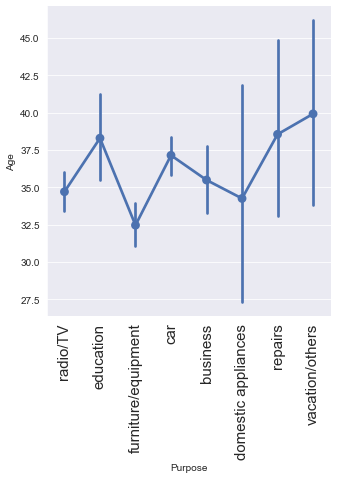

```python
sns.set({"figure.figsize": (10, 6)})
sns.catplot(data=data2, x="Purpose", y="Age", kind="point")
plt.xticks(rotation=90, fontsize=15)
```

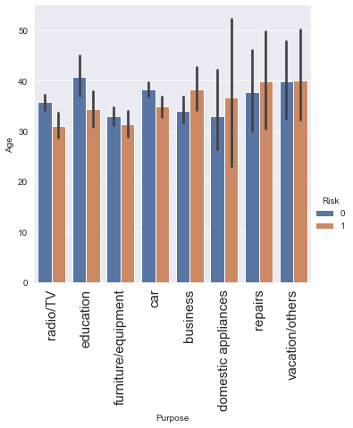

```python
sns.set({"figure.figsize": (10, 6)})
sns.catplot(data=data2, x="Purpose", y="Age", hue="Risk", kind="bar")
plt.xticks(rotation=90, fontsize=15)
```

- overall defaulters are mostly youngers than non-defaulters but when the purpose=business or domestic appliance then defaulters are mostly elder than non-defaulters

### Purpose vs Risk vs Duration

- more chances to default--high duration compare to customers having low duration
- more chance to default-- persons who have taken credit for vacation/education or for other purposes compare to others
- less chances to default-- persons who have taken credit for the purpose of radio/TV compare to others

```
(array([0, 1, 2, 3, 4, 5, 6, 7]),
 [Text(0, 0, 'radio/TV'),
```

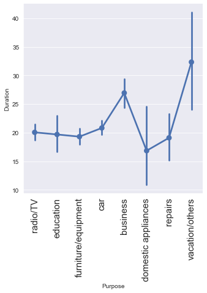

```python
sns.catplot(data=data2, x="Purpose", y="Duration", kind="point")
plt.xticks(rotation=90, fontsize=15)
```

- purpose and duration have relation in between them. There exists some collinearity
- it can say that vacation and business have high durations that's why they are more likely to default

```
(array([0, 1, 2, 3, 4, 5, 6, 7]),
 [Text(0, 0, 'radio/TV'),
```

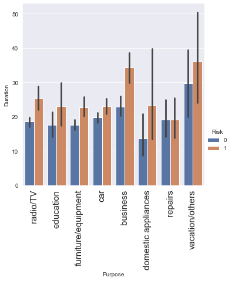

```python
sns.catplot(data=data2, x="Purpose", y="Duration", hue="Risk", kind="bar")
plt.xticks(rotation=90, fontsize=15)
```

- more chances to default--high duration compare to customers having low duration

### Credit amount vs Risk vs checkingaccount

- more chances to default--high credit amount compare to low credit amount customers
- more chances to default-- persons with little checking account compare to others

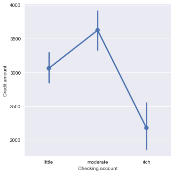

```python
sns.catplot(data=data2, x="Checking account", y="Credit amount", kind="point")
```

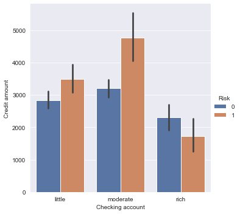

```python
sns.catplot(data=data2, x="Checking account", y="Credit amount", hue="Risk", kind="bar")
```

- defaulters will have high credit amount when checking account!=rich compare to non-defaulters
- defaulters will have low credit amount when checking account=rich compare to non-defaulters

### Credit amount vs Risk vs saving account

- more chances to default--high credit amount compare to low credit amount customers
- more chances to default-- persons who have little/moderate saving accounts compare to others

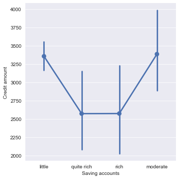

```python
sns.catplot(data=data2, x="Saving accounts", y="Credit amount", kind="point")
```

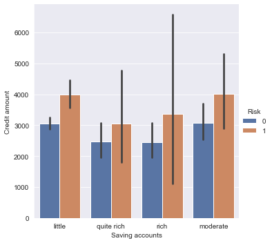

```python
sns.catplot(data=data2, x="Saving accounts", y="Credit amount", hue="Risk", kind="bar")
```

- more chances to default--high credit amount compare to low credit amount customers
- little and moderate have high credit amounts that's why there was more chances to default.
- high credit amounts lead to default instead little/moderate

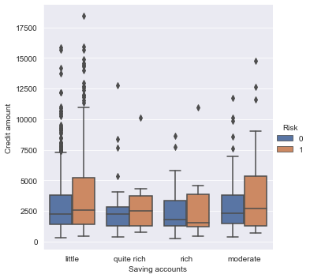

```python
sns.catplot(data=data2, x="Saving accounts", y="Credit amount", hue="Risk", kind="box")
```

# Overall Insights

- class distribution in the target variable is imbalanced , 70% observations for non-defaulters and 30% observations for defaulters
- The distribution of age is right-skewed, mean=35.5, median=33
  - more chances to default--younger customers compare to elder customers
  - defaulters who have housing=free, job=higly_skilled are elder than the non-defaulter
  - if purpose=business or domestic appliance then defaulters are mostly elder than non-defaulters
- The distribution of the credit amount is also right-skewed, mean=3271, median=2319
  - more chances to default--high credit amount compare to low credit amount customers
  - defaulters will have low credit amount when checking account=rich compare to non-defaulters
- The distribution of the duration for which the credit is given is right-skewed, mean=21, median=18
  - more chances to default--high duration compare to customers having low duration
- There are 69% male customers and 31% female customers
  - more chance to default-- female compare to male customers
- 63% skilled category, 22% unskilled, 15% highly skilled category
  - more chances to default-- highly skilled compare to others
  - most chance to default-- highly skilled and purpose=vacation/others
- 71% own house, 18% rented house, 11% free housing
  - more chances to default-- persons who have rent/free housing compare to others
  - less chance to default--samples having housing=rent, checking account=little and saving account!=little. i.e., 5 samples belong to that combination and all having risk=0
- 89% customers little or moderate savings account, 11% customers rich/quite-rich savings account
- 94% customers little or moderate checking account, 6% customers rich checking account
  - more chances to default-- persons with little checking account compare to moderate and rich checking accounts
  - least chances to default-- person having little checking account and rich/quite-rich saving account
  - least chance to default-- persons having little checking account, rich saving account and own the house i.e., there are total 4 samples in the dataset that have little+rich+own and all have risk=0
  - least chances to default-- person having rich checking account and any saving account except little
- most customers take credit for luxury items (i.e., car=33.7%, radio=28%, furniture=18.1%) less customers take credit for business(9.7%), education(5.9%) ,vacation-others(1.2%) etc
  - more chance to default-- persons who have taken credit for vacation-others, education or for repairs compare to other categories
  - less chance to default-- persons who have taken credit for radio/TV compare to other categories

## Model Building

### Model evaluation criterion

### Model can make wrong predictions as:

1. Predicting a customer is not going to default but in reality the customer will default - Loss of resources
2. Predicting a customer is going to default but in reality the customer will not default - Loss of opportunity

### Which Loss is greater ?

- Loss of resources will be the greater loss as the bank will be losing their resources i.e., profit/interest 10,000 on loan 100,000: if FP-> loss 10,000 profit but if FN-> loss 100,000 resources

### How to reduce this loss i.e need to reduce False Negatives ?

- Company would want to reduce false negatives, this can be done by maximizing the Recall. Greater the recall lesser the chances of false negatives.

#### As this is the exercise of logistic regression so we have selected logistic regression for our classifier, now need to select the values for their parameters

```python
data
```

|  | Age | Sex | Job | Housing | Saving accounts | Checking account | Credit amount | Duration | Risk | Purpose |
| --- | --- | --- | --- | --- | --- | --- | --- | --- | --- | --- |
| 0 | 67 | male | skilled | own | little | little | 1169 | 6 | 0 | radio/TV |
| 1 | 22 | female | skilled | own | little | moderate | 5951 | 48 | 1 | radio/TV |
| 2 | 49 | male | unskilled_and_non-resident | own | little | little | 2096 | 12 | 0 | education |
| 3 | 45 | male | skilled | free | little | little | 7882 | 42 | 0 | furniture/equipment |
| 4 | 53 | male | skilled | free | little | little | 4870 | 24 | 1 | car |
| ... | ... | ... | ... | ... | ... | ... | ... | ... | ... | ... |
| 995 | 31 | female | unskilled_and_non-resident | own | little | little | 1736 | 12 | 0 | furniture/equipment |
| 996 | 40 | male | highly skilled | own | little | little | 3857 | 30 | 0 | car |
| 997 | 38 | male | skilled | own | little | little | 804 | 12 | 0 | radio/TV |
| 998 | 23 | male | skilled | free | little | little | 1845 | 45 | 1 | radio/TV |
| 999 | 27 | male | skilled | own | moderate | moderate | 4576 | 45 | 0 | car |

1000 rows × 10 columns

#### Splitting into IVs and DV

```python
X = data.drop("Risk", axis=1)
y = data["Risk"]
```

#### Converting categorical to numerical columns

```python
X.select_dtypes(include="object").columns
```

```
Index(['Sex', 'Job', 'Housing', 'Saving accounts', 'Checking account',
       'Purpose'],
      dtype='object')
```

```python
# drop_first=True to get k-1 dummies out of k categorical levels by removing the first level.
X = pd.get_dummies(
    X,
    prefix=["Sex", "Housing", "Saving", "Checking", "Purpose"],
    columns=["Sex", "Housing", "Saving accounts", "Checking account", "Purpose"],
    drop_first=True,
)
X
```

|  | Age | Job | Credit amount | Duration | Sex_male | Housing_own | Housing_rent | Saving_moderate | Saving_quite rich | Saving_rich | Checking_moderate | Checking_rich | Purpose_car | Purpose_domestic appliances | Purpose_education | Purpose_furniture/equipment | Purpose_radio/TV | Purpose_repairs | Purpose_vacation/others |
| --- | --- | --- | --- | --- | --- | --- | --- | --- | --- | --- | --- | --- | --- | --- | --- | --- | --- | --- | --- |
| 0 | 67 | skilled | 1169 | 6 | 1 | 1 | 0 | 0 | 0 | 0 | 0 | 0 | 0 | 0 | 0 | 0 | 1 | 0 | 0 |
| 1 | 22 | skilled | 5951 | 48 | 0 | 1 | 0 | 0 | 0 | 0 | 1 | 0 | 0 | 0 | 0 | 0 | 1 | 0 | 0 |
| 2 | 49 | unskilled_and_non-resident | 2096 | 12 | 1 | 1 | 0 | 0 | 0 | 0 | 0 | 0 | 0 | 0 | 1 | 0 | 0 | 0 | 0 |
| 3 | 45 | skilled | 7882 | 42 | 1 | 0 | 0 | 0 | 0 | 0 | 0 | 0 | 0 | 0 | 0 | 1 | 0 | 0 | 0 |
| 4 | 53 | skilled | 4870 | 24 | 1 | 0 | 0 | 0 | 0 | 0 | 0 | 0 | 1 | 0 | 0 | 0 | 0 | 0 | 0 |
| ... | ... | ... | ... | ... | ... | ... | ... | ... | ... | ... | ... | ... | ... | ... | ... | ... | ... | ... | ... |
| 995 | 31 | unskilled_and_non-resident | 1736 | 12 | 0 | 1 | 0 | 0 | 0 | 0 | 0 | 0 | 0 | 0 | 0 | 1 | 0 | 0 | 0 |
| 996 | 40 | highly skilled | 3857 | 30 | 1 | 1 | 0 | 0 | 0 | 0 | 0 | 0 | 1 | 0 | 0 | 0 | 0 | 0 | 0 |
| 997 | 38 | skilled | 804 | 12 | 1 | 1 | 0 | 0 | 0 | 0 | 0 | 0 | 0 | 0 | 0 | 0 | 1 | 0 | 0 |
| 998 | 23 | skilled | 1845 | 45 | 1 | 0 | 0 | 0 | 0 | 0 | 0 | 0 | 0 | 0 | 0 | 0 | 1 | 0 | 0 |
| 999 | 27 | skilled | 4576 | 45 | 1 | 1 | 0 | 1 | 0 | 0 | 1 | 0 | 1 | 0 | 0 | 0 | 0 | 0 | 0 |

1000 rows × 19 columns

```python
X = pd.get_dummies(X, prefix=["Job"], columns=["Job"],)
X
```

|  | Age | Credit amount | Duration | Sex_male | Housing_own | Housing_rent | Saving_moderate | Saving_quite rich | Saving_rich | Checking_moderate | Checking_rich | Purpose_car | Purpose_domestic appliances | Purpose_education | Purpose_furniture/equipment | Purpose_radio/TV | Purpose_repairs | Purpose_vacation/others | Job_highly skilled | Job_skilled | Job_unskilled_and_non-resident |
| --- | --- | --- | --- | --- | --- | --- | --- | --- | --- | --- | --- | --- | --- | --- | --- | --- | --- | --- | --- | --- | --- |
| 0 | 67 | 1169 | 6 | 1 | 1 | 0 | 0 | 0 | 0 | 0 | 0 | 0 | 0 | 0 | 0 | 1 | 0 | 0 | 0 | 1 | 0 |
| 1 | 22 | 5951 | 48 | 0 | 1 | 0 | 0 | 0 | 0 | 1 | 0 | 0 | 0 | 0 | 0 | 1 | 0 | 0 | 0 | 1 | 0 |
| 2 | 49 | 2096 | 12 | 1 | 1 | 0 | 0 | 0 | 0 | 0 | 0 | 0 | 0 | 1 | 0 | 0 | 0 | 0 | 0 | 0 | 1 |
| 3 | 45 | 7882 | 42 | 1 | 0 | 0 | 0 | 0 | 0 | 0 | 0 | 0 | 0 | 0 | 1 | 0 | 0 | 0 | 0 | 1 | 0 |
| 4 | 53 | 4870 | 24 | 1 | 0 | 0 | 0 | 0 | 0 | 0 | 0 | 1 | 0 | 0 | 0 | 0 | 0 | 0 | 0 | 1 | 0 |
| ... | ... | ... | ... | ... | ... | ... | ... | ... | ... | ... | ... | ... | ... | ... | ... | ... | ... | ... | ... | ... | ... |
| 995 | 31 | 1736 | 12 | 0 | 1 | 0 | 0 | 0 | 0 | 0 | 0 | 0 | 0 | 0 | 1 | 0 | 0 | 0 | 0 | 0 | 1 |
| 996 | 40 | 3857 | 30 | 1 | 1 | 0 | 0 | 0 | 0 | 0 | 0 | 1 | 0 | 0 | 0 | 0 | 0 | 0 | 1 | 0 | 0 |
| 997 | 38 | 804 | 12 | 1 | 1 | 0 | 0 | 0 | 0 | 0 | 0 | 0 | 0 | 0 | 0 | 1 | 0 | 0 | 0 | 1 | 0 |
| 998 | 23 | 1845 | 45 | 1 | 0 | 0 | 0 | 0 | 0 | 0 | 0 | 0 | 0 | 0 | 0 | 1 | 0 | 0 | 0 | 1 | 0 |
| 999 | 27 | 4576 | 45 | 1 | 1 | 0 | 1 | 0 | 0 | 1 | 0 | 1 | 0 | 0 | 0 | 0 | 0 | 0 | 0 | 1 | 0 |

1000 rows × 21 columns

```python
data.select_dtypes(include="object").nunique()
```

```
Sex                 2
Job                 3
Housing             3
Saving accounts     4
Checking account    3
Purpose             8
dtype: int64
```

```python
data["Job"].unique()
```

```
array(['skilled', 'unskilled_and_non-resident', 'highly skilled'],
      dtype=object)
```

- Job have 3 dummy columns because in the description of job, there are total 4 categories. i.e., unskilled_and_resident not in the given dataset but mentioned in description of attributes

#### Train-test split

```python
# splitting in training and test set
X_train, X_test, y_train, y_test = train_test_split(
    X, y, test_size=0.3, random_state=42
)
```

```python
print(X_train.shape)
print(y_train.shape)
print(X_test.shape)
print(y_test.shape)
```

```
(700, 21)
(700,)
(300, 21)
(300,)
```

```python
data2.select_dtypes(exclude="object").columns.values
```

```
array(['Age', 'Credit amount', 'Duration'], dtype=object)
```

```python
continuous_col = data2.select_dtypes(exclude="object").columns.values
```

### Standard Scaling

```python
from sklearn.preprocessing import StandardScaler

std_scale = StandardScaler()
X_train[continuous_col] = std_scale.fit_transform(X_train[continuous_col])
```

```python
X_test[continuous_col] = std_scale.transform(X_test[continuous_col])
```

### Hyperparameter Tuning

```python
len(np.arange(0.007, 0.5, 0.01))
```

```
50
```

```python
np.arange(0.007, 0.5, 0.01)
```

```
array([0.007, 0.017, 0.027, 0.037, 0.047, 0.057, 0.067, 0.077, 0.087,
       0.097, 0.107, 0.117, 0.127, 0.137, 0.147, 0.157, 0.167, 0.177,
       0.187, 0.197, 0.207, 0.217, 0.227, 0.237, 0.247, 0.257, 0.267,
       0.277, 0.287, 0.297, 0.307, 0.317, 0.327, 0.337, 0.347, 0.357,
       0.367, 0.377, 0.387, 0.397, 0.407, 0.417, 0.427, 0.437, 0.447,
       0.457, 0.467, 0.477, 0.487, 0.497])
```

```python
parameters = {
    "C": np.arange(0.007, 0.5, 0.01),
    "solver": ["liblinear", "newton-cg", "lbfgs", "sag", "saga"],
    "penalty": ["l1", "l2"],
}
```

```python
cls = GridSearchCV(
    LogisticRegression(random_state=1, tol=0.00001, max_iter=1000),
    parameters,
    scoring="roc_auc",
)
cls.fit(X_train, y_train)
```

```
GridSearchCV(estimator=LogisticRegression(max_iter=1000, random_state=1,
                                          tol=1e-05),
             param_grid={'C': array([0.007, 0.017, 0.027, 0.037, 0.047, 0.057, 0.067, 0.077, 0.087,
       0.097, 0.107, 0.117, 0.127, 0.137, 0.147, 0.157, 0.167, 0.177,
       0.187, 0.197, 0.207, 0.217, 0.227, 0.237, 0.247, 0.257, 0.267,
       0.277, 0.287, 0.297, 0.307, 0.317, 0.327, 0.337, 0.347, 0.357,
       0.367, 0.377, 0.387, 0.397, 0.407, 0.417, 0.427, 0.437, 0.447,
       0.457, 0.467, 0.477, 0.487, 0.497]),
                         'penalty': ['l1', 'l2'],
                         'solver': ['liblinear', 'newton-cg', 'lbfgs', 'sag',
                                    'saga']},
             scoring='roc_auc')
```

```python
df_tuning = pd.DataFrame.from_dict(cls.cv_results_)
df_tuning
```

|  | mean_fit_time | std_fit_time | mean_score_time | std_score_time | param_C | param_penalty | param_solver | params | split0_test_score | split1_test_score | split2_test_score | split3_test_score | split4_test_score | mean_test_score | std_test_score | rank_test_score |
| --- | --- | --- | --- | --- | --- | --- | --- | --- | --- | --- | --- | --- | --- | --- | --- | --- |
| 0 | 0.007379 | 0.004438 | 0.007789 | 0.005074 | 0.007 | l1 | liblinear | {'C': 0.007, 'penalty': 'l1', 'solver': 'libli... | 0.500000 | 0.500000 | 0.500000 | 0.500000 | 0.500000 | 0.500000 | 0.000000 | 348 |
| 1 | 0.001993 | 0.001542 | 0.000000 | 0.000000 | 0.007 | l1 | newton-cg | {'C': 0.007, 'penalty': 'l1', 'solver': 'newto... | NaN | NaN | NaN | NaN | NaN | NaN | NaN | 368 |
| 2 | 0.003989 | 0.004136 | 0.000000 | 0.000000 | 0.007 | l1 | lbfgs | {'C': 0.007, 'penalty': 'l1', 'solver': 'lbfgs'} | NaN | NaN | NaN | NaN | NaN | NaN | NaN | 371 |
| 3 | 0.001396 | 0.000798 | 0.000000 | 0.000000 | 0.007 | l1 | sag | {'C': 0.007, 'penalty': 'l1', 'solver': 'sag'} | NaN | NaN | NaN | NaN | NaN | NaN | NaN | 381 |
| 4 | 0.008327 | 0.005354 | 0.002789 | 0.000397 | 0.007 | l1 | saga | {'C': 0.007, 'penalty': 'l1', 'solver': 'saga'} | 0.500000 | 0.500000 | 0.500000 | 0.500000 | 0.500000 | 0.500000 | 0.000000 | 348 |
| ... | ... | ... | ... | ... | ... | ... | ... | ... | ... | ... | ... | ... | ... | ... | ... | ... |
| 495 | 0.005378 | 0.002347 | 0.003805 | 0.001724 | 0.497 | l2 | liblinear | {'C': 0.4970000000000001, 'penalty': 'l2', 'so... | 0.725302 | 0.656220 | 0.617590 | 0.677600 | 0.693149 | 0.673972 | 0.036083 | 218 |
| 496 | 0.025126 | 0.003655 | 0.003989 | 0.000631 | 0.497 | l2 | newton-cg | {'C': 0.4970000000000001, 'penalty': 'l2', 'so... | 0.724809 | 0.656948 | 0.618319 | 0.677114 | 0.693149 | 0.674068 | 0.035634 | 202 |
| 497 | 0.020944 | 0.004040 | 0.004589 | 0.002721 | 0.497 | l2 | lbfgs | {'C': 0.4970000000000001, 'penalty': 'l2', 'so... | 0.724809 | 0.656948 | 0.618319 | 0.676871 | 0.693149 | 0.674019 | 0.035630 | 217 |
| 498 | 0.016953 | 0.001668 | 0.004788 | 0.002221 | 0.497 | l2 | sag | {'C': 0.4970000000000001, 'penalty': 'l2', 'so... | 0.724809 | 0.656948 | 0.618319 | 0.677114 | 0.693149 | 0.674068 | 0.035634 | 202 |
| 499 | 0.035910 | 0.002979 | 0.003788 | 0.000746 | 0.497 | l2 | saga | {'C': 0.4970000000000001, 'penalty': 'l2', 'so... | 0.724809 | 0.656948 | 0.618319 | 0.677114 | 0.693149 | 0.674068 | 0.035634 | 202 |

500 rows × 16 columns

```python
len(df_tuning)
```

```
500
```

```python
cls.best_params_
```

```
{'C': 0.007, 'penalty': 'l2', 'solver': 'liblinear'}
```

```python
cls.best_estimator_
```

```
LogisticRegression(C=0.007, max_iter=1000, random_state=1, solver='liblinear',
                   tol=1e-05)
```

```python
cls.best_score_
```

```
0.6797044253241367
```

### Model training

```python
model = LogisticRegression(
    C=0.007, max_iter=1000, random_state=1, solver="liblinear", penalty="l2", tol=1e-05
)
```

```python
model.fit(X_train, y_train)
```

```
LogisticRegression(C=0.007, max_iter=1000, random_state=1, solver='liblinear',
                   tol=1e-05)
```

#### Finding the coefficients

```python
model.coef_
```

```
array([[-0.14885639,  0.10908344,  0.17113594, -0.18020321, -0.22271969,
        -0.00447155, -0.0041274 , -0.05022245, -0.04623858, -0.1276686 ,
        -0.03269373, -0.02693284,  0.00472689,  0.02121707, -0.05478225,
        -0.14289508, -0.00305503,  0.0045199 , -0.03103163, -0.11773703,
        -0.04331463]])
```

```python
log_odds_ratio = model.coef_[0]
```

```python
model.intercept_
```

```
array([-0.19208329])
```

```python
pd.DataFrame(log_odds_ratio, X_train.columns, columns=["coef"]).T
```

|  | Age | Credit amount | Duration | Sex_male | Housing_own | Housing_rent | Saving_moderate | Saving_quite rich | Saving_rich | Checking_moderate | Checking_rich | Purpose_car | Purpose_domestic appliances | Purpose_education | Purpose_furniture/equipment | Purpose_radio/TV | Purpose_repairs | Purpose_vacation/others | Job_highly skilled | Job_skilled | Job_unskilled_and_non-resident |
| --- | --- | --- | --- | --- | --- | --- | --- | --- | --- | --- | --- | --- | --- | --- | --- | --- | --- | --- | --- | --- | --- |
| coef | -0.148856 | 0.109083 | 0.171136 | -0.180203 | -0.22272 | -0.004472 | -0.004127 | -0.050222 | -0.046239 | -0.127669 | -0.032694 | -0.026933 | 0.004727 | 0.021217 | -0.054782 | -0.142895 | -0.003055 | 0.00452 | -0.031032 | -0.117737 | -0.043315 |

#### Coefficient interpretations

- Coefficients of Credit amount, Duration and some categorical levels of Purpose are positive, an increase in values of these variables (or variable=1) will lead to an increase in chances of a customer being a defaulter.
- Coefficients of Age, Sex_male, Housing, Saving accounts, checking accounts ,job and some categorical levels of Purpose are negative, an increase in values of these variables (or variable=1) will lead to a decrease in chances of a customer being a defaulter.

#### Converting coefficients(log odds_ratio) to odds_ratio

- The coefficients of the logistic regression model are in terms of log(odds_ratio), to find the odds_ratio we have to take the exponential of the coefficients.
- b=log(odds_ratio), and b is any coefficient
- Therefore, **odds_ratio = exp(b)**
- The percentage change in odds is given as **odds = (exp(b) - 1) * 100**

```python
# converting log_odds_ratio to odds_ratio

odds_ratio = np.exp(log_odds_ratio)

# finding the percentage change
perc_change_odds = (odds_ratio - 1) * 100
```

```python
pd.DataFrame(
    {"coef": log_odds_ratio, "odds_ratio": odds_ratio, "Change_odd%": perc_change_odds},
    index=X_train.columns,
).T
```

|  | Age | Credit amount | Duration | Sex_male | Housing_own | Housing_rent | Saving_moderate | Saving_quite rich | Saving_rich | Checking_moderate | Checking_rich | Purpose_car | Purpose_domestic appliances | Purpose_education | Purpose_furniture/equipment | Purpose_radio/TV | Purpose_repairs | Purpose_vacation/others | Job_highly skilled | Job_skilled | Job_unskilled_and_non-resident |
| --- | --- | --- | --- | --- | --- | --- | --- | --- | --- | --- | --- | --- | --- | --- | --- | --- | --- | --- | --- | --- | --- |
| coef | -0.148856 | 0.109083 | 0.171136 | -0.180203 | -0.222720 | -0.004472 | -0.004127 | -0.050222 | -0.046239 | -0.127669 | -0.032694 | -0.026933 | 0.004727 | 0.021217 | -0.054782 | -0.142895 | -0.003055 | 0.004520 | -0.031032 | -0.117737 | -0.043315 |
| odds_ratio | 0.861693 | 1.115255 | 1.186652 | 0.835100 | 0.800339 | 0.995538 | 0.995881 | 0.951018 | 0.954814 | 0.880145 | 0.967835 | 0.973427 | 1.004738 | 1.021444 | 0.946691 | 0.866845 | 0.996950 | 1.004530 | 0.969445 | 0.888930 | 0.957610 |
| Change_odd% | -13.830715 | 11.525540 | 18.665205 | -16.489950 | -19.966084 | -0.446157 | -0.411890 | -4.898215 | -4.518587 | -11.985499 | -3.216506 | -2.657339 | 0.473807 | 2.144375 | -5.330874 | -13.315499 | -0.305037 | 0.453013 | -3.055509 | -11.107022 | -4.238995 |

```python
std_scale.mean_
```

```
array([  35.49285714, 3406.81571429,   21.25285714])
```

```python
np.sqrt(std_scale.var_)
```

```
array([  11.24499662, 2969.77386518,   11.89154828])
```

### Coefficient interpretations:

- `Age`: 13.83% decrease in odds of a customer being a defaulter by increasing the age by one unit(11.25 years), holding all other features constant at certain value.
- `Credit Amount`: 11.53% increase in odds of a customer being a defaulter by increasing the credit amount by one unit(2970 DM), holding all other features constant at certain value.
- `Duration`: 18.67% increase in odds of a customer being a defaulter by increasing the duration by one unit(11.9 months), holding all other features constant at certain value.
- `Sex_male`: odds of a male customer being a defaulter is 16.49% lesser than the female customer, holding all other features constant at certain value.
- `Housing`: odds of a customer who has own house being a defaulter is 19.97% lesser than the customers who has free house. And odds of a customer who has rented house being a defaulter is 0.44% lesser than the customers who has free house.[keeping housing_free as reference] Holding all other features constant at certain value.

Interpretation for other attributes can be made similarly

### Reason of using scaled dataset:

```python
X_train2 = X_train.copy()

X_train2[continuous_col] = std_scale.inverse_transform(X_train[continuous_col])
```

```python
model2 = LogisticRegression(
    C=0.007, max_iter=1000, random_state=1, solver="liblinear", penalty="l2", tol=1e-05
)
model2.fit(X_train2, y_train)


log_odds_ratio = model2.coef_[0]
odds_ratio = np.exp(log_odds_ratio)
perc_change_odds = (odds_ratio - 1) * 100

pd.DataFrame(
    {"coef": log_odds_ratio, "odds_ratio": odds_ratio, "Change_odd%": perc_change_odds},
    index=X_train2.columns,
).T
```

|  | Age | Credit amount | Duration | Sex_male | Housing_own | Housing_rent | Saving_moderate | Saving_quite rich | Saving_rich | Checking_moderate | Checking_rich | Purpose_car | Purpose_domestic appliances | Purpose_education | Purpose_furniture/equipment | Purpose_radio/TV | Purpose_repairs | Purpose_vacation/others | Job_highly skilled | Job_skilled | Job_unskilled_and_non-resident |
| --- | --- | --- | --- | --- | --- | --- | --- | --- | --- | --- | --- | --- | --- | --- | --- | --- | --- | --- | --- | --- | --- |
| coef | -0.037826 | 0.000047 | 0.024317 | -0.077866 | -0.123075 | 0.024606 | 0.004093 | -0.040580 | -0.035109 | -0.065251 | -0.016542 | 0.041149 | 0.007704 | 0.036158 | -0.028367 | -0.104316 | 0.002645 | 0.006747 | 0.006144 | -0.034850 | 0.006095 |
| odds_ratio | 0.962880 | 1.000047 | 1.024615 | 0.925088 | 0.884198 | 1.024911 | 1.004101 | 0.960233 | 0.965500 | 0.936832 | 0.983595 | 1.042008 | 1.007734 | 1.036819 | 0.972031 | 0.900941 | 1.002648 | 1.006770 | 1.006163 | 0.965750 | 1.006113 |
| Change_odd% | -3.711994 | 0.004738 | 2.461510 | -7.491190 | -11.580250 | 2.491124 | 0.410095 | -3.976744 | -3.449998 | -6.316781 | -1.640546 | 4.200756 | 0.773374 | 3.681913 | -2.796850 | -9.905945 | 0.264824 | 0.677005 | 0.616308 | -3.424986 | 0.611319 |

#### Just consider credit_amount (coef or odds% )

- In case of unscaled data: 0.000047/0.0047%
  - It seems that this coefficient has the very least impact on the odds of being a defaulter
  - Yes, of course, we can measure the strength of the impact on odds by the coefficient. But a smaller coefficient can be due to both reasons, one is in lesser relation with the target column and the second is due to unscaled data w.r.t to other variables. So when a variable has larger values compared to other variables then during training smaller coefficient can be, to avoid bias in the model towards a particular variable(just due to the reason of larger values).
  - 0.0047% increase in odds of belonging to default, when credit amount increased by one unit(1 DM).
  - In another sense, if you will consider this dataset then you will get the idea that values in the credit amount are not increasing or decreasing by 1 DM. But in the case of a categorical variable, with the change of the variable's value, direct category change
- In case of scaled data: 0.1/11.53%
  - 11.5% increase in odds of belonging to default, when credit amount increase by one unit(2970DM)
  - Easy to compare the impact of this variable(coefficients) with other variables when data is scaled.

## Checking model's performance

```python
# defining a function to compute different metrics to check performance of a classification model built using sklearn

def model_performance_classification_sklearn_with_threshold(model, predictors, target, threshold=0.5):
    """
    Function to compute different metrics, based on the threshold specified, to check classification model performance

    model: classifier
    predictors: independent variables
    target: dependent variable
    threshold: threshold for classifying the observation as class 1
    """

    # predicting using the independent variables
    pred_prob = model.predict_proba(predictors)[:, 1]
    pred =binarize(pred_prob.reshape(len(pred_prob), 1), threshold=threshold)



    acc = accuracy_score(target, pred)  # to compute Accuracy
    recall = recall_score(target, pred)  # to compute Recall
    precision = precision_score(target, pred)  # to compute Precision
    f1 = f1_score(target, pred)  # to compute F1-score

    # creating a dataframe of metrics
    df_perf = pd.DataFrame(
        {
            "Accuracy": acc,
            "Recall": recall,
            "Precision": precision,
            "F1": f1,
        },
        index=[0],
    )

    return df_perf
```

```python
model_performance_classification_sklearn_with_threshold(model, X_test, y_test)
```

|  | Accuracy | Recall | Precision | F1 |
| --- | --- | --- | --- | --- |
| 0 | 0.716667 | 0.065934 | 1.0 | 0.123711 |

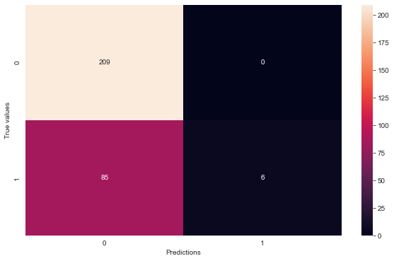

```python
sns.heatmap(confusion_matrix(y_test, model.predict(X_test)), annot=True, fmt=".4g")
plt.xlabel("Predictions")
plt.ylabel("True values")
```

```python
# On training dataset
roc_auc_score(y_train, model.predict_proba(X_train)[:, 1])
```

```
0.6946861692279208
```

```python
# On testing dataset

# roc_auc_score(y_test, model.decision_function(X_test))
roc_auc_score(y_test, model.predict_proba(X_test)[:, 1])
```

```
0.6377306903622694
```

### Threshold Setting

```python
precisions, recalls, thresholds = precision_recall_curve(
    y_test, model.predict_proba(X_test)[:, 1]
)
```

```python
def plot_precision_recall_vs_threshold(precisions, recalls, thresholds):
    plt.title('Precision_Recall Curve')
    sns.lineplot(thresholds, precisions[:-1],label='precisions');
    sns.lineplot(thresholds, recalls[:-1],label='recalls');
    plt.xlabel('Threshold')
    plt.legend();
```

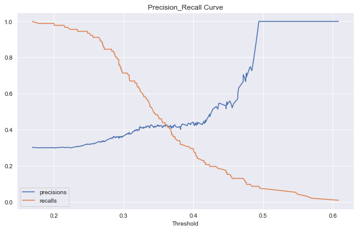

```python
plot_precision_recall_vs_threshold(precisions, recalls, thresholds)
```

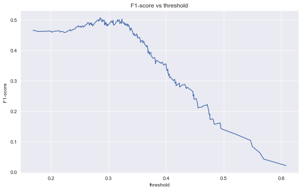

```python
plt.title("F1-score vs threshold")
sns.lineplot(thresholds, ((2 * precisions * recalls) / (precisions + recalls))[:-1])
plt.xlabel("threshold")
plt.ylabel("F1-score ")
```

#### Optimal threshold

```python
f1scores = (2 * precisions * recalls) / (precisions + recalls)
optimal_t = thresholds[np.argmax(f1scores)]
print(
    "Maximum f1_score: ",
    np.max(f1scores),
    "at threshold: ",
    thresholds[np.argmax(f1scores)],
)
```

```
Maximum f1_score:  0.5066666666666667 at threshold:  0.28563865259771143
```

```python
model_performance_classification_sklearn_with_threshold(
    model, X_test, y_test, optimal_t
)
```

|  | Accuracy | Recall | Precision | F1 |
| --- | --- | --- | --- | --- |
| 0 | 0.503333 | 0.824176 | 0.360577 | 0.501672 |

```python
y_pred2 = binarize(model.predict_proba(X_test)[:, 1:2], threshold=0.2856)
y_pred2
```

[output not shown]

[output cut: 245 more lines]

```
       [1.],
       [1.],
       [0.],
       [1.],
       [1.],
       [1.],
       [1.],
       [1.],
       [1.],
       [1.],
       [1.],
       [1.],
       [1.],
       [1.],
       [1.]])
```

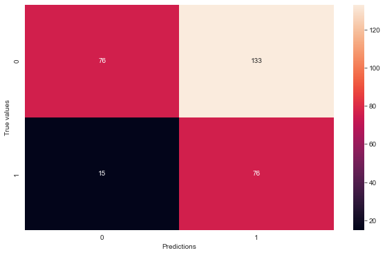

```python
sns.heatmap(confusion_matrix(y_test, y_pred2), annot=True, fmt=".4g")
plt.xlabel("Predictions")
plt.ylabel("True values")
```

### additional (threshold setting)

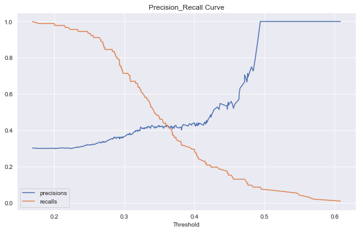

```python
plot_precision_recall_vs_threshold(precisions, recalls, thresholds)
```

```python
req_threshold = np.round(thresholds[(np.argmin(recalls >= 0.9)) - 1], 3)
req_threshold
```

```
0.266
```

```python
model_performance_classification_sklearn_with_threshold(
    model, X_test, y_test, req_threshold
)
```

|  | Accuracy | Recall | Precision | F1 |
| --- | --- | --- | --- | --- |
| 0 | 0.423333 | 0.901099 | 0.333333 | 0.486647 |

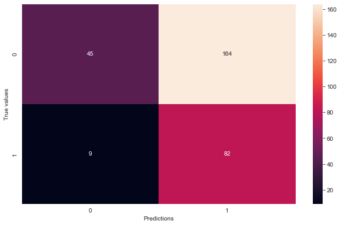

```python
sns.heatmap(
    confusion_matrix(
        y_test, binarize(model.predict_proba(X_test)[:, 1:2], threshold=req_threshold)
    ),
    annot=True,
    fmt=".4g",
)
plt.xlabel("Predictions")
plt.ylabel("True values")
```

### Important Features SFS

```python
lr = LogisticRegression(
    C=0.007, max_iter=1000, random_state=1, solver="liblinear", penalty="l2", tol=1e-05
)

# Build step forward feature selection
sfs = SFS(
    lr,
    k_features=X_train.shape[1],
    forward=True,  # k_features denotes the number of features to select
    floating=False,
    scoring="roc_auc",
    n_jobs=-1,  # n_jobs=-1 means all processor cores will be used
    verbose=1,
    cv=5,
)

# Perform SFFS
sfs = sfs.fit(X_train, y_train)
```

[output not shown]

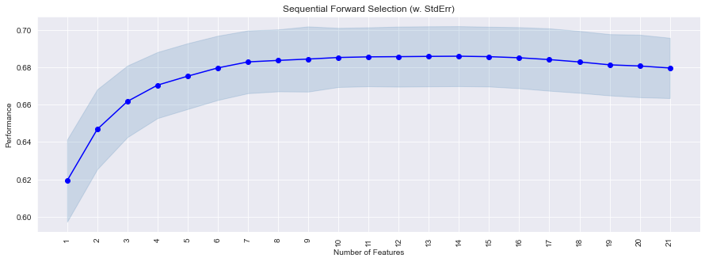

```python
# to plot the performance with addition of each feature
from mlxtend.plotting import plot_sequential_feature_selection as plot_sfs

fig1 = plot_sfs(sfs.get_metric_dict(), kind="std_err", figsize=(15, 5))
plt.title("Sequential Forward Selection (w. StdErr)")
plt.xticks(rotation=90)
plt.show()
```

```python
sfs.subsets_
```

```
{1: {'feature_idx': (2,),
  'cv_scores': array([0.61172703, 0.54871234, 0.60932945, 0.64443635, 0.68221574]),
  'avg_score': 0.6192841807824385,
  'feature_names': ('Duration',)},
 2: {'feature_idx': (0, 2),
  'cv_scores': array([0.63168268, 0.6180758 , 0.63423226, 0.61868319, 0.73153547]),
  'avg_score': 0.6468418810877744,
  'feature_names': ('Age', 'Duration')},
 3: {'feature_idx': (0, 2, 15),
  'cv_scores': array([0.66100025, 0.64358601, 0.62913022, 0.63945578, 0.73578717]),
  'avg_score': 0.6617918860079138,
  'feature_names': ('Age', 'Duration', 'Purpose_radio/TV')},
 4: {'feature_idx': (0, 2, 4, 15),
  'cv_scores': array([0.67134762, 0.61977648, 0.65779883, 0.67371234, 0.72995627]),
  'avg_score': 0.670518309741804,
  'feature_names': ('Age', 'Duration', 'Housing_own', 'Purpose_radio/TV')},
 5: {'feature_idx': (0, 2, 3, 4, 15),
  'cv_scores': array([0.68551367, 0.61868319, 0.67456268, 0.66897473, 0.72886297]),
  'avg_score': 0.6753194499212418,
  'feature_names': ('Age',
   'Duration',
   'Sex_male',
   'Housing_own',
   'Purpose_radio/TV')},
 6: {'feature_idx': (0, 1, 2, 3, 4, 15),
  'cv_scores': array([0.68785415, 0.63119534, 0.66618076, 0.67614189, 0.73736638]),
  'avg_score': 0.6797477010020564,
  'feature_names': ('Age',
   'Credit amount',
   'Duration',
   'Sex_male',
   'Housing_own',
   'Purpose_radio/TV')},
 7: {'feature_idx': (0, 1, 2, 3, 4, 9, 15),
  'cv_scores': array([0.69672333, 0.65306122, 0.64480078, 0.68148688, 0.7388241 ]),
  'avg_score': 0.6829792628697556,
  'feature_names': ('Age',
   'Credit amount',
   'Duration',
   'Sex_male',
```

[output cut: 323 more lines]

```
   'Saving_moderate',
   'Saving_quite rich',
   'Saving_rich',
   'Checking_moderate',
   'Checking_rich',
   'Purpose_car',
   'Purpose_domestic appliances',
   'Purpose_education',
   'Purpose_furniture/equipment',
   'Purpose_radio/TV',
   'Purpose_repairs',
   'Purpose_vacation/others',
   'Job_highly skilled',
   'Job_skilled',
   'Job_unskilled_and_non-resident')}}
```

```python
X_train.columns[[0, 1, 2, 3, 4, 5, 7, 8, 9, 13, 14, 15, 16, 17]]
```

```
Index(['Age', 'Credit amount', 'Duration', 'Sex_male', 'Housing_own',
       'Housing_rent', 'Saving_quite rich', 'Saving_rich', 'Checking_moderate',
       'Purpose_education', 'Purpose_furniture/equipment', 'Purpose_radio/TV',
       'Purpose_repairs', 'Purpose_vacation/others'],
      dtype='object')
```

```python
selected_cols = X_train.columns[[0, 1, 2, 3, 4, 5, 7, 8, 9, 13, 14, 15, 16, 17]]
```

```python
X_train3 = X_train[selected_cols]
X_test3 = X_test[selected_cols]
```

```python
model3 = LogisticRegression(
    C=0.007, max_iter=1000, random_state=1, solver="liblinear", penalty="l2", tol=1e-05
)
model3.fit(X_train3, y_train)
```

```
LogisticRegression(C=0.007, max_iter=1000, random_state=1, solver='liblinear',
                   tol=1e-05)
```

```python
print("*************Selected features*************")
# On training dataset
print(
    "On training dataset", roc_auc_score(y_train, model3.predict_proba(X_train3)[:, 1])
)

# On testing dataset
print("On testing dataset", roc_auc_score(y_test, model3.predict_proba(X_test3)[:, 1]))
```

```
*************Selected features*************
On training dataset 0.6944912735458346
On testing dataset 0.6342604763657397
```

```python
print("*************All features*************")
# On training dataset
print("On training dataset", roc_auc_score(y_train, model.predict_proba(X_train)[:, 1]))

# On testing dataset
print("On testing dataset", roc_auc_score(y_test, model.predict_proba(X_test)[:, 1]))
```

```
*************All features*************
On training dataset 0.6946861692279208
On testing dataset 0.6377306903622694
```

```python
print("*************Selected features*************")
precisions3, recalls3, thresholds3 = precision_recall_curve(
    y_test, model3.predict_proba(X_test3)[:, 1]
)

f1scores3 = (2 * precisions3 * recalls3) / (precisions3 + recalls3)
optimal_t3 = thresholds3[np.argmax(f1scores3)]
print(
    "Maximum f1_score: ",
    np.max(f1scores3),
    "at threshold: ",
    thresholds3[np.argmax(f1scores3)],
)
model_performance_classification_sklearn_with_threshold(
    model3, X_test3, y_test, optimal_t3
)
```

```
*************Selected features*************
Maximum f1_score:  0.5 at threshold:  0.3296757892210945
```

|  | Accuracy | Recall | Precision | F1 |
| --- | --- | --- | --- | --- |
| 0 | 0.61 | 0.626374 | 0.407143 | 0.493506 |

```python
print("*************All features*************")
model_performance_classification_sklearn_with_threshold(
    model, X_test, y_test, optimal_t
)
```

```
*************All features*************
```

|  | Accuracy | Recall | Precision | F1 |
| --- | --- | --- | --- | --- |
| 0 | 0.503333 | 0.824176 | 0.360577 | 0.501672 |

```python
optimal_t
```

```
0.28563865259771143
```

## Recommendations

- From our logistic regression model we identified that Duration is significant predictor of a customer being a defaulter.
- back should target the customers who has their own houses
- Bank should target more male customers as they have lesser odds of defaulting.
- We saw in our analysis that customers with a little or moderate amount in saving or checking accounts are more likely to default. The bank can be more strict with its rules or interest rates to compensate for the risk.
- We saw that customers who have rented or free housing are more likely to default. The bank should keep more details about such customers like hometown addresses, etc. to be able to track them.
- Our analysis showed that younger customers are slightly more likely to default. The bank can alter its policies to deal with this.